# CKME136 Capstone - Cleaning and Exploratory Analysis of Diabetes Readmission Data

## Variables by Readmission Status

We will compare each variable against the target variable (readmitted) to identify differences between the two groups: patients who were readmitted within 30 days, and patients who weren’t.

### Numeric Variables by Readmission Status

For numeric variables, the count, mean, standard deviation, and boxplots will be compared between both groups. Additionally, a sample t-test will be completed to test for a statistically significant difference between the two groups.

**Time in Hospital VS Readmitted**

```r
group_by(db.expl, readmitted) %>%
  summarise(count = n(), mean = mean(time_in_hospital), sd = sd(time_in_hospital)) # The mean for time in hospital for the <30 group is slightly higher than the not readmitted group, with a slightly higher standard deviation as well.
```

```
## # A tibble: 2 x 4
##   readmitted count  mean    sd
##   <fct>      <int> <dbl> <dbl>
## 1 <30         6277  4.80  3.06
## 2 Not<30     63696  4.22  2.92
```

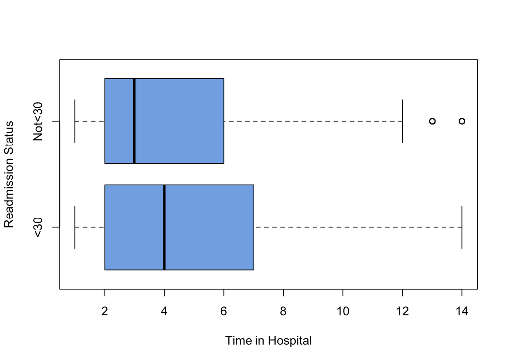

```r
boxplot(time_in_hospital~readmitted, data=db.expl, horizontal = T, col = '#83afe6', xlab = "Time in Hospital", ylab = "Readmission Status") # Visualize the two groups
```

```r
# Test whether the mean of the <30 group is significantly higher than the Not<30 group; no need to test for normality as sample sizes are large (central limit theorem). First check to see if the variances are equal using an f-test to inform the t-test arguments
var.test(time_in_hospital ~ readmitted, data = db.expl) # Variances are not equal (p=2.644e-07)
```

```
##
##  F test to compare two variances
##
## data:  time_in_hospital by readmitted
## F = 1.0996, num df = 6276, denom df = 63695, p-value = 2.644e-07
## alternative hypothesis: true ratio of variances is not equal to 1
## 95 percent confidence interval:
##  1.060322 1.141018
## sample estimates:
## ratio of variances
##           1.099623
```

```r
t.test(db.expl$time_in_hospital[db.expl$readmitted == "<30"], db.expl$time_in_hospital[db.expl$readmitted == "Not<30"], alternative = "greater", var.equal = FALSE) # The finding that the mean for the <30 group is higher than the Not<30 group is highly significant (p<2.2e-16). Therefore, there is a longer average length of stay for patients who are readmitted within 30 days
```

```
##
##  Welch Two Sample t-test
##
## data:  db.expl$time_in_hospital[db.expl$readmitted == "<30"] and db.expl$time_in_hospital[db.expl$readmitted == "Not<30"]
## t = 14.286, df = 7445.4, p-value < 2.2e-16
## alternative hypothesis: true difference in means is greater than 0
## 95 percent confidence interval:
##  0.5093295       Inf
## sample estimates:
## mean of x mean of y
##  4.797196  4.221584
```

**Number of Lab Procedures VS Readmitted**

```r
group_by(db.expl, readmitted) %>%
  summarise(count = n(), mean = mean(num_lab_procedures), sd = sd(num_lab_procedures)) # The mean for number of lab procedures for the <30 group is slightly higher than the not readmitted group, with a slightly lower standard deviation
```

```
## # A tibble: 2 x 4
##   readmitted count  mean    sd
##   <fct>      <int> <dbl> <dbl>
## 1 <30         6277  44.9  19.3
## 2 Not<30     63696  42.7  19.9
```

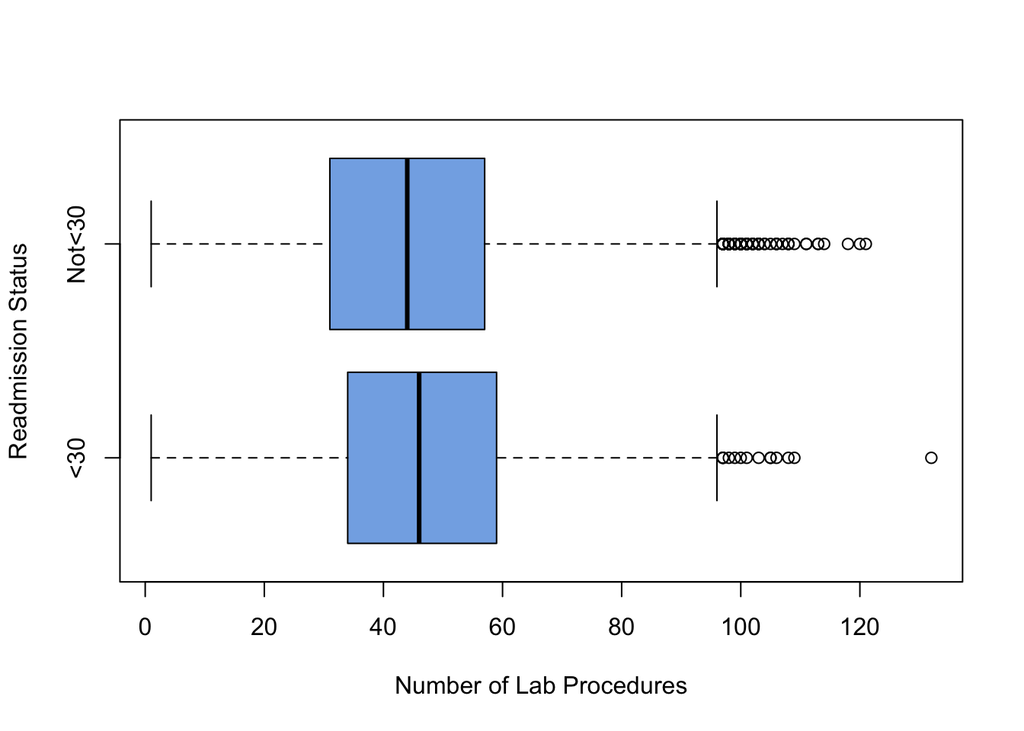

```r
boxplot(num_lab_procedures~readmitted, data=db.expl, horizontal = T, col = '#83afe6', xlab = "Number of Lab Procedures", ylab = "Readmission Status")
```

```r
var.test(num_lab_procedures ~ readmitted, data = db.expl) # Variances of the two groups are not equal (p=0.001259)
```

```
##
##  F test to compare two variances
##
## data:  num_lab_procedures by readmitted
## F = 0.94087, num df = 6276, denom df = 63695, p-value = 0.001259
## alternative hypothesis: true ratio of variances is not equal to 1
## 95 percent confidence interval:
##  0.9072466 0.9762929
## sample estimates:
## ratio of variances
##          0.9408736
```

```r
t.test(db.expl$num_lab_procedures[db.expl$readmitted == "<30"], db.expl$num_lab_procedures[db.expl$readmitted == "Not<30"], alternative = "greater", var.equal = FALSE) # The finding that the mean for the <30 group is higher than the Not<30 group is highly significant (p<2.2e-16). Therefore, there is a higher average number of lab procedures completed for patients who are readmitted within 30 days
```

```
##
##  Welch Two Sample t-test
##
## data:  db.expl$num_lab_procedures[db.expl$readmitted == "<30"] and db.expl$num_lab_procedures[db.expl$readmitted == "Not<30"]
## t = 8.7323, df = 7651.3, p-value < 2.2e-16
## alternative hypothesis: true difference in means is greater than 0
## 95 percent confidence interval:
##  1.818288      Inf
## sample estimates:
## mean of x mean of y
##  44.91541  42.67507
```

**Number of Procedures VS Readmitted**

```r
group_by(db.expl, readmitted) %>%
  summarise(count = n(), mean = mean(num_procedures), sd = sd(num_procedures)) # The means and standard deviations are very close for both groups
```

```
## # A tibble: 2 x 4
##   readmitted count  mean    sd
##   <fct>      <int> <dbl> <dbl>
## 1 <30         6277  1.42  1.73
## 2 Not<30     63696  1.43  1.76
```

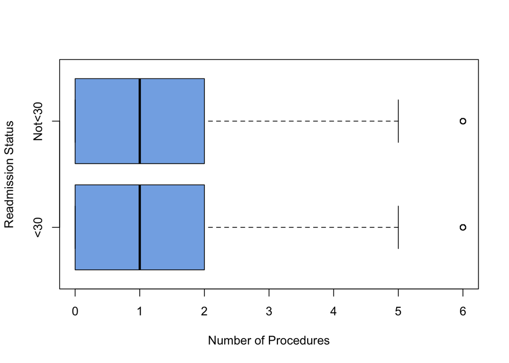

```r
boxplot(num_procedures~readmitted, data=db.expl, horizontal = T, col = '#83afe6', xlab = "Number of Procedures", ylab = "Readmission Status") # Distributions look identical
```

```r
var.test(num_procedures ~ readmitted, data = db.expl) # Fail to reject the null hypothesis that the variances are equal (p=0.07307)
```

```
##
##  F test to compare two variances
##
## data:  num_procedures by readmitted
## F = 0.96678, num df = 6276, denom df = 63695, p-value = 0.07307
## alternative hypothesis: true ratio of variances is not equal to 1
## 95 percent confidence interval:
##  0.9322232 1.0031703
## sample estimates:
## ratio of variances
##          0.9667759
```

```r
t.test(num_procedures~readmitted, data=db.expl, var.equal = TRUE) # Fail to reject the null hypothesis that the means are the same (p=0.9695)
```

```
##
##  Two Sample t-test
##
## data:  num_procedures by readmitted
## t = -0.038297, df = 69971, p-value = 0.9695
## alternative hypothesis: true difference in means is not equal to 0
## 95 percent confidence interval:
##  -0.04645152  0.04467105
## sample estimates:
##    mean in group <30 mean in group Not<30
##             1.424725             1.425615
```

**Number of Medications VS Readmitted**

```r
group_by(db.expl, readmitted) %>%
  summarise(count = n(), mean = mean(num_medications), sd = sd(num_medications)) # The mean and standard deviation of the <30 group is slightly higher
```

```
## # A tibble: 2 x 4
##   readmitted count  mean    sd
##   <fct>      <int> <dbl> <dbl>
## 1 <30         6277  16.6  8.32
## 2 Not<30     63696  15.6  8.28
```

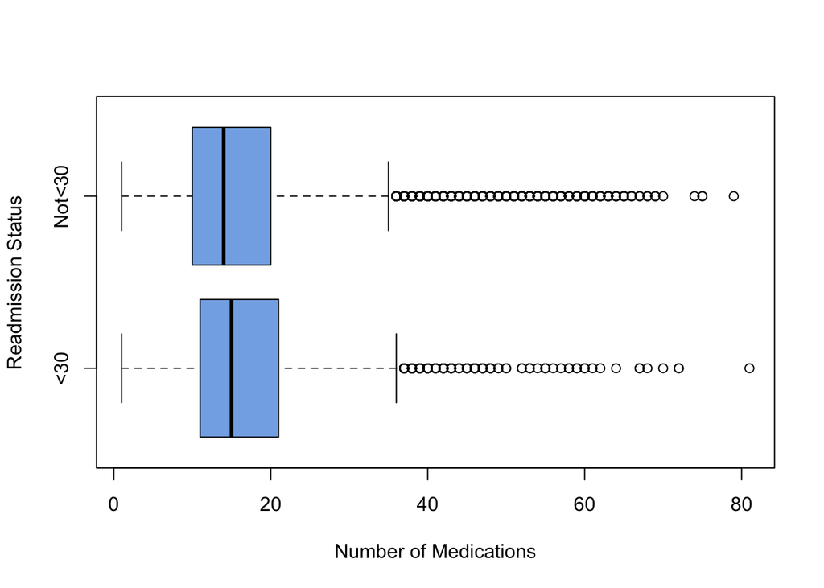

```r
boxplot(num_medications~readmitted, data=db.expl, horizontal = T, col = '#83afe6', xlab = "Number of Medications", ylab = "Readmission Status") # Distributions look similar
```

```r
var.test(num_medications ~ readmitted, data = db.expl) # Fail to reject the null hypothesis that the variances are equal (p=0.5465)
```

```
##
##  F test to compare two variances
##
## data:  num_medications by readmitted
## F = 1.0112, num df = 6276, denom df = 63695, p-value = 0.5465
## alternative hypothesis: true ratio of variances is not equal to 1
## 95 percent confidence interval:
##  0.9750895 1.0492990
## sample estimates:
## ratio of variances
##           1.011231
```

```r
t.test(db.expl$num_medications[db.expl$readmitted == "<30"], db.expl$num_medications[db.expl$readmitted == "Not<30"], alternative = "greater", var.equal = TRUE)  # The results are highly significant (p<2.2e-16) that the mean of the <30 group is greater than the Not<30 group. Therefore, the average number of medications for those readmitted within 30 days is higher than those not readmitted within 30 days
```

```
##
##  Two Sample t-test
##
## data:  db.expl$num_medications[db.expl$readmitted == "<30"] and db.expl$num_medications[db.expl$readmitted == "Not<30"]
## t = 9.6309, df = 69971, p-value < 2.2e-16
## alternative hypothesis: true difference in means is greater than 0
## 95 percent confidence interval:
##  0.8749603       Inf
## sample estimates:
## mean of x mean of y
##  16.62578  15.57060
```

**Number of Outpatient Visits VS Readmitted**

```r
group_by(db.expl, readmitted) %>%
  summarise(count = n(), mean = mean(number_outpatient), sd = sd(number_outpatient)) # The mean of the <30 group is slightly higher, while the sd is slightly lower
```

```
## # A tibble: 2 x 4
##   readmitted count  mean    sd
##   <fct>      <int> <dbl> <dbl>
## 1 <30         6277 0.308  1.04
## 2 Not<30     63696 0.277  1.07
```

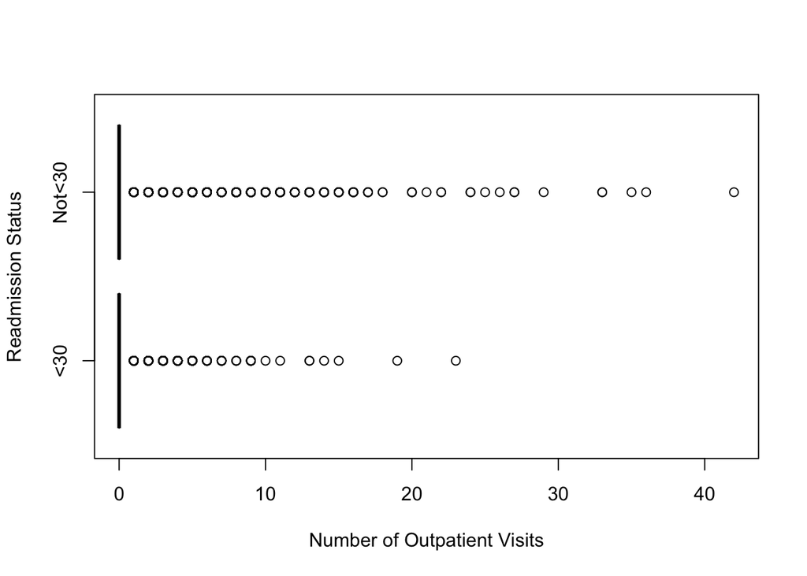

```r
boxplot(number_outpatient~readmitted, data=db.expl, horizontal = T, col = '#83afe6', xlab = "Number of Outpatient Visits", ylab = "Readmission Status") # Distributions look similar, with fewer outliers for <30
```

```r
var.test(number_outpatient ~ readmitted, data = db.expl) # Can reject the null hypothesis at the alpha=0.05 level that the variances are equal (p=0.03272)
```

```
##
##  F test to compare two variances
##
## data:  number_outpatient by readmitted
## F = 0.96053, num df = 6276, denom df = 63695, p-value = 0.03272
## alternative hypothesis: true ratio of variances is not equal to 1
## 95 percent confidence interval:
##  0.9261983 0.9966869
## sample estimates:
## ratio of variances
##          0.9605277
```

```r
t.test(db.expl$number_outpatient[db.expl$readmitted == "<30"], db.expl$number_outpatient[db.expl$readmitted == "Not<30"], alternative = "greater", var.equal = FALSE)  # The results are statistically significant (p=0.01096) that the mean of the <30 group is greater than the Not<30 group. Therefore, the average number of outpatient visits in the last year for those readmitted within 30 days is higher than those not readmitted within 30 days.
```

```
##
##  Welch Two Sample t-test
##
## data:  db.expl$number_outpatient[db.expl$readmitted == "<30"] and db.expl$number_outpatient[db.expl$readmitted == "Not<30"]
## t = 2.2924, df = 7621.9, p-value = 0.01096
## alternative hypothesis: true difference in means is greater than 0
## 95 percent confidence interval:
##  0.008962153         Inf
## sample estimates:
## mean of x mean of y
## 0.3084276 0.2766893
```

**Number of Emergency Visits VS Readmitted**

```r
group_by(db.expl, readmitted) %>%
  summarise(count = n(), mean = mean(number_emergency), sd = sd(number_emergency)) # The mean and standard deviation of the <30 group are higher
```

```
## # A tibble: 2 x 4
##   readmitted count   mean    sd
##   <fct>      <int>  <dbl> <dbl>
## 1 <30         6277 0.150  0.582
## 2 Not<30     63696 0.0994 0.504
```

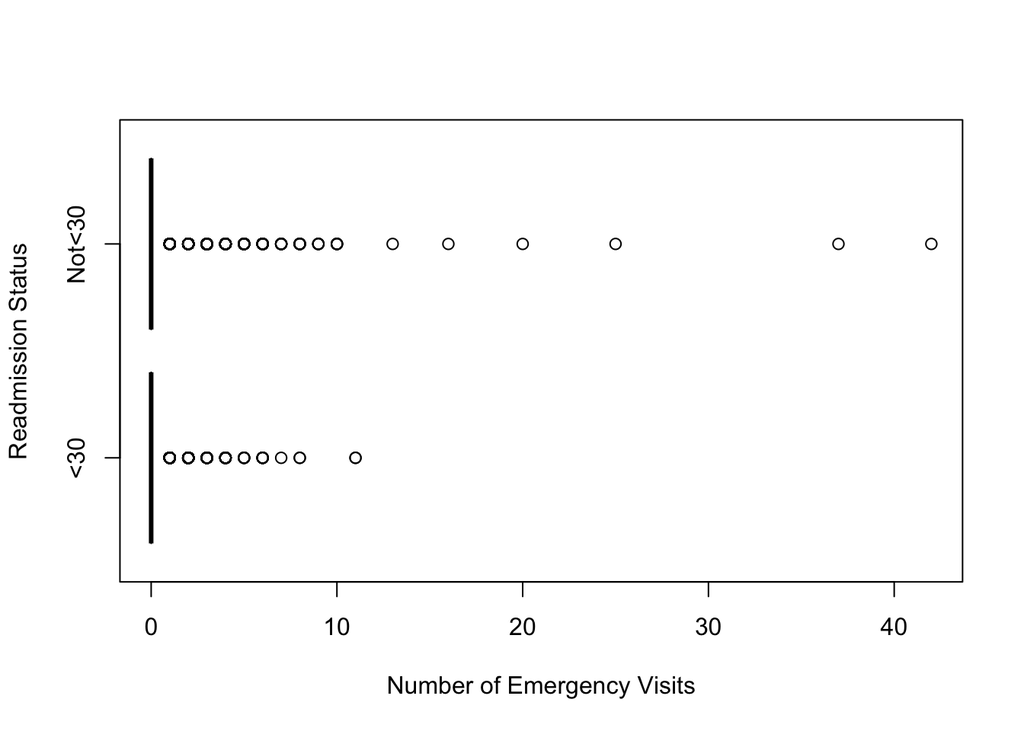

```r
boxplot(number_emergency~readmitted, data=db.expl, horizontal = T, col = '#83afe6', xlab = "Number of Emergency Visits", ylab = "Readmission Status") # Distributions look similar, with fewer outliers for <30
```

```r
var.test(number_emergency ~ readmitted, data = db.expl) # Cannot consider the variances to be equal (p<2.2e-16)
```

```
##
##  F test to compare two variances
##
## data:  number_emergency by readmitted
## F = 1.3333, num df = 6276, denom df = 63695, p-value < 2.2e-16
## alternative hypothesis: true ratio of variances is not equal to 1
## 95 percent confidence interval:
##  1.285695 1.383543
## sample estimates:
## ratio of variances
##           1.333349
```

```r
t.test(db.expl$number_emergency[db.expl$readmitted == "<30"], db.expl$number_emergency[db.expl$readmitted == "Not<30"], alternative = "greater", var.equal = FALSE)  # The results are highly significant (p=2.016e-11) that the mean of the <30 group is greater than the Not<30 group. Therefore, the average number of emergency visits in the last year for those readmitted within 30 days is higher than those not readmitted within 30 days
```

```
##
##  Welch Two Sample t-test
##
## data:  db.expl$number_emergency[db.expl$readmitted == "<30"] and db.expl$number_emergency[db.expl$readmitted == "Not<30"]
## t = 6.6131, df = 7234.1, p-value = 2.016e-11
## alternative hypothesis: true difference in means is greater than 0
## 95 percent confidence interval:
##  0.0378318       Inf
## sample estimates:
## mean of x mean of y
## 0.1497531 0.0993940
```

**Number of Inpatient Visits VS Readmitted**

```r
group_by(db.expl, readmitted) %>%
  summarise(count = n(), mean = mean(number_inpatient), sd = sd(number_inpatient)) # The mean of the <30 group is over double the mean of Not<30. The sd is higher as well
```

```
## # A tibble: 2 x 4
##   readmitted count  mean    sd
##   <fct>      <int> <dbl> <dbl>
## 1 <30         6277 0.369 0.983
## 2 Not<30     63696 0.157 0.546
```

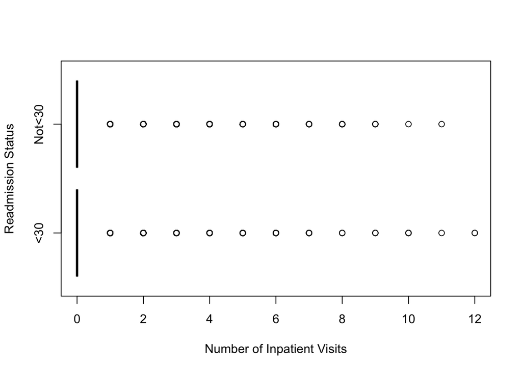

```r
boxplot(number_inpatient~readmitted, data=db.expl, horizontal = T, col = '#83afe6', xlab = "Number of Inpatient Visits", ylab = "Readmission Status") # We're not able to see much here
```

```r
var.test(number_inpatient ~ readmitted, data = db.expl) # Variances are not equal (p<2.2e-16)
```

```
##
##  F test to compare two variances
##
## data:  number_inpatient by readmitted
## F = 3.2355, num df = 6276, denom df = 63695, p-value < 2.2e-16
## alternative hypothesis: true ratio of variances is not equal to 1
## 95 percent confidence interval:
##  3.119891 3.357331
## sample estimates:
## ratio of variances
##           3.235529
```

```r
t.test(db.expl$number_inpatient[db.expl$readmitted == "<30"], db.expl$number_inpatient[db.expl$readmitted == "Not<30"], alternative = "greater", var.equal = FALSE)  # The findings are highly significant (p<2.2e-16) that the mean of the <30 group is greater than the Not<30 group. Therefore, the average number of inpatient visits in the last year for those readmitted within 30 days is higher than those not readmitted within 30 days
```

```
##
##  Welch Two Sample t-test
##
## data:  db.expl$number_inpatient[db.expl$readmitted == "<30"] and db.expl$number_inpatient[db.expl$readmitted == "Not<30"]
## t = 16.799, df = 6663.5, p-value < 2.2e-16
## alternative hypothesis: true difference in means is greater than 0
## 95 percent confidence interval:
##  0.1908144       Inf
## sample estimates:
## mean of x mean of y
## 0.3688068 0.1572783
```

**Number of Diagnoses VS Readmitted**

```r
group_by(db.expl, readmitted) %>%
  summarise(count = n(), mean = mean(number_diagnoses), sd = sd(number_diagnoses)) # The mean of the <30 group is higher than the Not<30 group while the sd is lower
```

```
## # A tibble: 2 x 4
##   readmitted count  mean    sd
##   <fct>      <int> <dbl> <dbl>
## 1 <30         6277  7.51  1.85
## 2 Not<30     63696  7.20  2.01
```

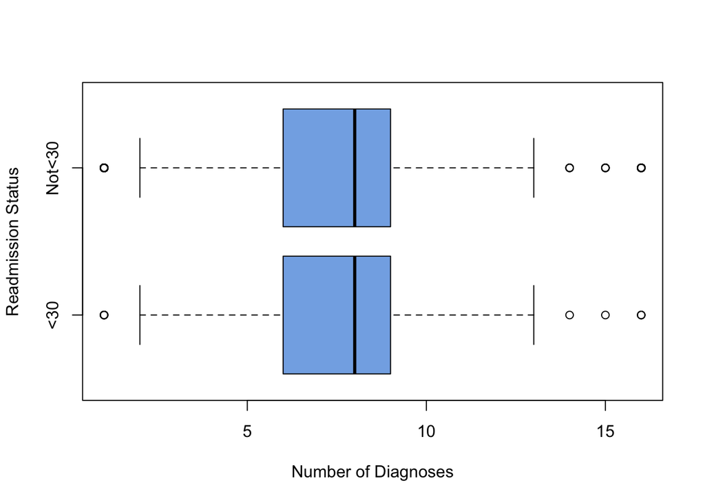

```r
boxplot(number_diagnoses~readmitted, data=db.expl, horizontal = T, col = '#83afe6', xlab = "Number of Diagnoses", ylab = "Readmission Status") # The distributions appear identical here
```

```r
var.test(number_diagnoses ~ readmitted, data = db.expl) # Variances are not equal (p<2.2e-16)
```

```
##
##  F test to compare two variances
##
## data:  number_diagnoses by readmitted
## F = 0.84113, num df = 6276, denom df = 63695, p-value < 2.2e-16
## alternative hypothesis: true ratio of variances is not equal to 1
## 95 percent confidence interval:
##  0.8110711 0.8727979
## sample estimates:
## ratio of variances
##          0.8411333
```

```r
t.test(db.expl$number_diagnoses[db.expl$readmitted == "<30"], db.expl$number_diagnoses[db.expl$readmitted == "Not<30"], alternative = "greater", var.equal = FALSE)  # Highly significant (p<2.2e-16) that the mean of the <30 group is greater than the Not<30 group. Therefore, the average number of diagnoses for those readmitted within 30 days is higher than those not readmitted within 30 days
```

```
##
##  Welch Two Sample t-test
##
## data:  db.expl$number_diagnoses[db.expl$readmitted == "<30"] and db.expl$number_diagnoses[db.expl$readmitted == "Not<30"]
## t = 12.903, df = 7822.1, p-value < 2.2e-16
## alternative hypothesis: true difference in means is greater than 0
## 95 percent confidence interval:
##  0.277388      Inf
## sample estimates:
## mean of x mean of y
##  7.513143  7.195224
```